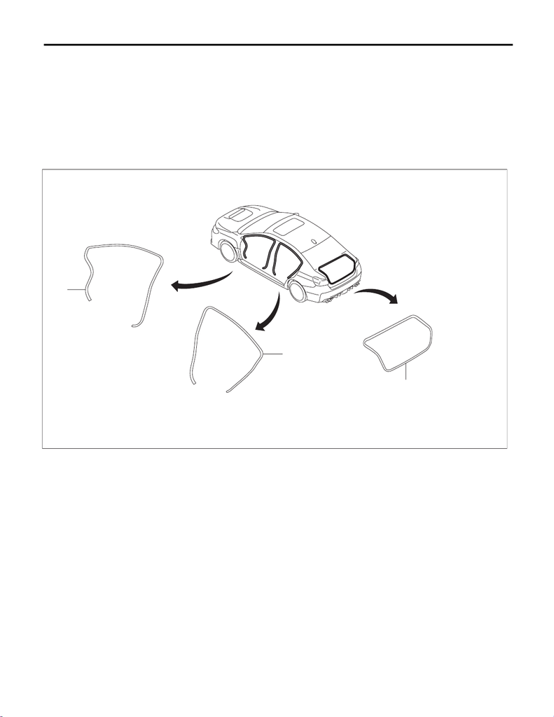

Weather Strip

EXTERIOR BODY PANELS

10.Weather Strip

A: REPLACEMENT

1. FLANGE

1) Remove each weather strip - body side flange while pulling the rubber. Be careful not to tear the rubber.

NOTE:

side.

(1) Weather strip - body side flange

front

(2) Weather strip - body side flange

rear

(3) Weather strip - trunk lid

EB-00957

(1)

(2)

(3)

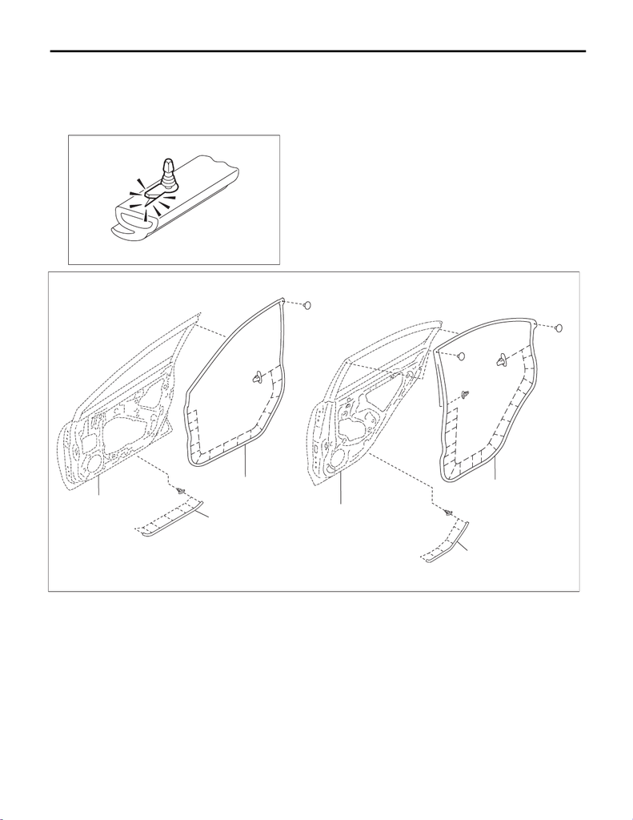

Weather Strip

EXTERIOR BODY PANELS

2. DOOR

1) Remove the weather strip after removing the clip. Be careful not to tear the rubber.

CAUTION:

to use clip remover to remove.

EB-00141

(1) Panel ASSY - front door (3) Weather strip - front door (5) Weather strip - rear door - lower

(2) Weather strip - front door - lower (4) Panel ASSY - rear door (6) Weather strip - rear door

EB-00956

(1)

(2)

(4)

(5)

(6)

(3)

[figure not shown]

Weather Strip

EXTERIOR BODY PANELS

[figure not shown]

CRUISE CONTROL SYSTEM

CC

Page

2. Relay and Fuse ..........................................................................................3

3. Cruise Control System ...............................................................................4

4. Cruise Control Module ...............................................................................5

5. Cruise Control Command Switch ...............................................................6

6. Combination Meter .....................................................................................8

7. Stop Light & Brake Switch ..........................................................................9

8. Clutch Switch ...........................................................................................10

9. Inhibitor Switch .........................................................................................11

10. Transmission Control Module (TCM) .......................................................12

11. Neutral Position Switch ............................................................................13

12. Diagnostics with Phenomenon .................................................................14